# What Factors Most Impact Student Performance?

You can see that the factors for Math are significantly fewer compared to the factors for Portuguese. This could be because there is not enough data in the Math dataset, since there were only 395 values compared to 649. As a result, a lot of the data could be skewed or missing.

For our machine learning, we will use linear regression on these factors picked above and determine the coefficient for determination for each one to see which factor explains the final grade the best. The function below separates the data passed in into training and testing sets. We use the training sets to train the model to find the least squares regression line that best matches the data, and then use this line to predict it on the testing data. We then calculate a coefficient of determination to see how well the linear regression line matches the testing data. We use the sklearn's linear_model library to accomplish this. You can learn more about it here at https://scikit-learn.org/stable/modules/generated/sklearn.linear_model.LogisticRegression.htmlent.

```python
def linear_regression(X, Y):
    X_train, X_test, Y_train, Y_test = train_test_split(X, Y, test_size=0.2)
    model.fit(X_train, Y_train)
    Y_predict = model.predict(X_test)

    r_squared = model.score(X_test, Y_test)
    print('Coefficients: ', model.coef_[0])
    print('Intercept: ', model.intercept_)
    print(f"Coefficient of Determination: {r_squared}")

    plt.scatter(X, Y)
    plt.plot(X_test, Y_predict, color = 'black')
    plt.show()
```

```
Coefficients:  [2.09845824]
Intercept:  [10.50273224]
Coefficient of Determination: 0.011516426877292707
```

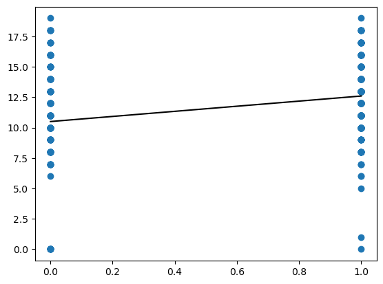

```python
X = por_dataframe[['school']]
Y = por_dataframe[['Portuguese Final Grade']]
linear_regression(X, Y)
```

```
Coefficients:  [-1.00520253]
Intercept:  [12.25641026]
Coefficient of Determination: -0.018624109274250733
```

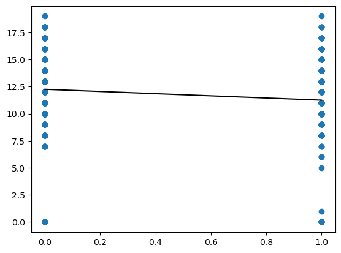

```python
X = por_dataframe[['sex']]
Y = por_dataframe[['Portuguese Final Grade']]
linear_regression(X, Y)
```

```
Coefficients:  [0.98460357]
Intercept:  [9.96234685]
Coefficient of Determination: 0.06895773262005522
```

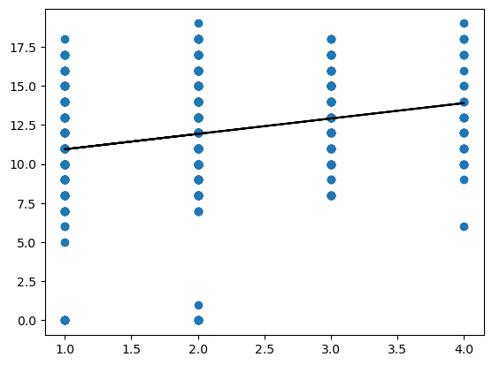

```python
X = por_dataframe[['studytime']]
Y = por_dataframe[['Portuguese Final Grade']]
linear_regression(X, Y)
```

```
Coefficients:  [-2.22059837]
Intercept:  [12.44066863]
Coefficient of Determination: 0.15720827291449457
```

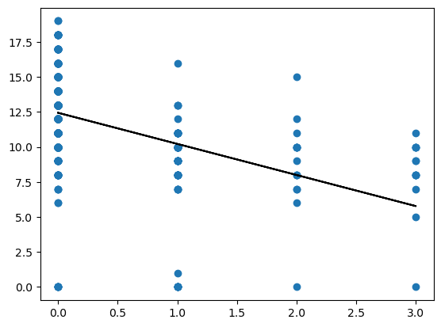

```python
X = por_dataframe[['Failures Before Portuguese Class']]
Y = por_dataframe[['Portuguese Final Grade']]
linear_regression(X, Y)
```

```
Coefficients:  [-0.93576017]
Intercept:  [11.93576017]
Coefficient of Determination: -0.019988108617999156
```

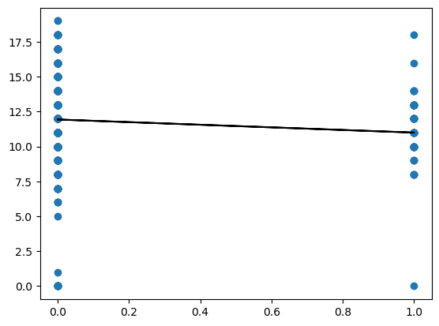

```python
X = por_dataframe[['schoolsup']]
Y = por_dataframe[['Portuguese Final Grade']]
linear_regression(X, Y)
```

```
Coefficients:  [3.34755078]
Intercept:  [8.98148148]
Coefficient of Determination: 0.10990277446555308
```

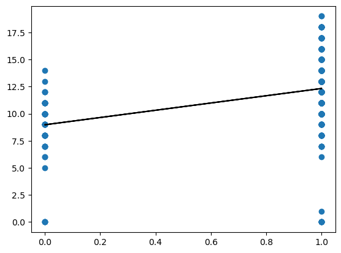

```python
X = por_dataframe[['higher']]
Y = por_dataframe[['Portuguese Final Grade']]
linear_regression(X, Y)
```

```
Coefficients:  [-0.22815326]
Intercept:  [12.75843396]
Coefficient of Determination: 0.001795858569794584
```

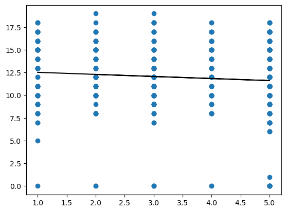

```python
X = por_dataframe[['health']]
Y = por_dataframe[['Portuguese Final Grade']]
linear_regression(X, Y)
```

```
Coefficients:  [0.65613]
Intercept:  [9.99421965]
Coefficient of Determination: 0.012260869228357785
```

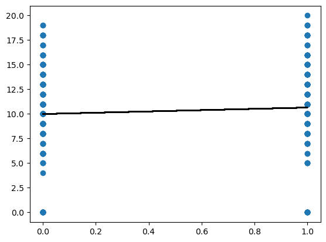

```python
X = math_dataframe[['sex']]
Y = math_dataframe[['Math Final Grade']]
linear_regression(X, Y)
```

```
Coefficients:  [-2.15455154]
Intercept:  [10.97879938]
Coefficient of Determination: 0.2070231183430309
```

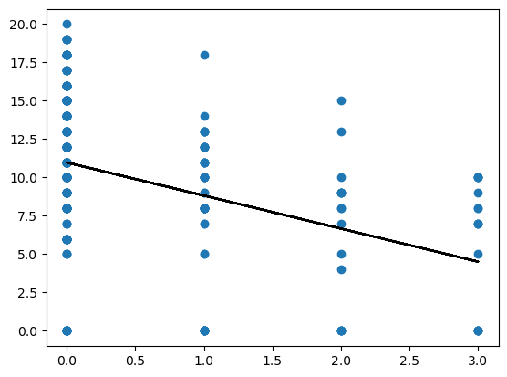

```python
X = math_dataframe[['Failures Before Math Class']]
Y = math_dataframe[['Math Final Grade']]
linear_regression(X, Y)
```

```
Coefficients:  [-1.10260267]
Intercept:  [10.69483568]
Coefficient of Determination: 0.024091549138080093
```

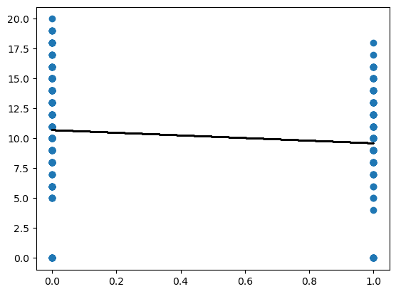

```python
X = math_dataframe[['romantic']]
Y = math_dataframe[['Math Final Grade']]
linear_regression(X, Y)
```

```
Coefficients:  [-0.50208411]
Intercept:  [12.20271868]
Coefficient of Determination: -0.035182404437028136
```

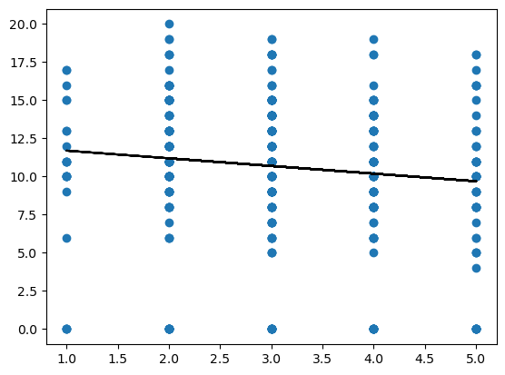

```python
X = math_dataframe[['goout']]
Y = math_dataframe[['Math Final Grade']]
linear_regression(X, Y)
```

# Interpretation: Insight & Conclusions

Based off these results alone, it would seem that a student having previous failures in other classes would have the biggest impact on their grade as for both datasets, this factor had the highest coefficient of determination. However, we cannot say for sure. We only performed our linear regression training algorithm on these two datasets once, which isn't enough to fully determine whether these results are accurate. In order to achieve greater accuracy, we could've run the algorithm using multiple different training and testing sets and recalculating the coefficient of determination each time. Also, we should keep in mind that our dataset only took students from two high schools in Portugal, which is not representative of all high school students worldwide. However, this was just a basic dive into a highly complex subject with a myriad of factors, and with further time and resources spent developing this project, we may be able to generalize our results to a bigger population.